# Introduction to R

Fall 2018

## Minervo

**Innovative and meaningfull approach to informal education.**

- Interactive and practical workshops
- Social impact
- Networking
- Afordable
- Nice and inspiring environment

## About the tutor

Experience:

- Data scientist at Quichesoft - fuel price optimization
- Data scientist at RTSmunity - esport betting
- Credit risk analyst at Ernst & Young
- Financial analyst at Raiffeisenbank

Hobbies:

- Sport - american football, tenis
- Education - machine learning, AI

Me & R:

- 6 years of experience - statistical modelling, vizualization, data analysis
- 2 years full-time - programming, package development

## About You

**>> Who are you and what do you work on?**

**>> Where and why do you use R nowadays?**

**>> What do you expect from today's workshop?**

## Goals of this workshop

1. Understand the basics of R language
2. Be able to perform simple manipulation of a data frame
3. Vizualize your data and communicate results

## You will learn…

- The **tidyverse** approach to R
- How to use RStudio efficiently
- How to load and manipulate data
- How to visualize your data
- How to automate your daily tasks in simple scripts
- How to generate reports and analyses w/o any effort

*… not today but throughout all three parts.*

## Base R

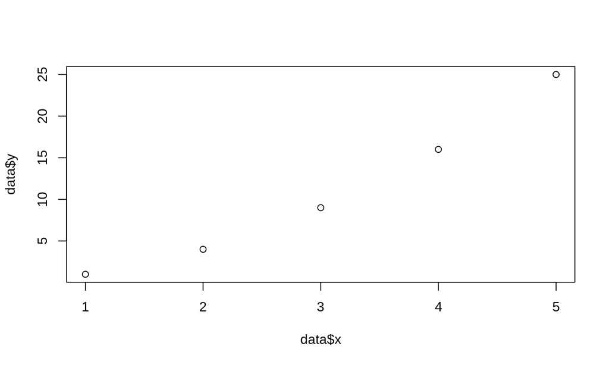

```r
data <- data.frame(x = 1:5)
data$y <- data$x^2
plot(data$x, data$y)
```

## Tidyverse

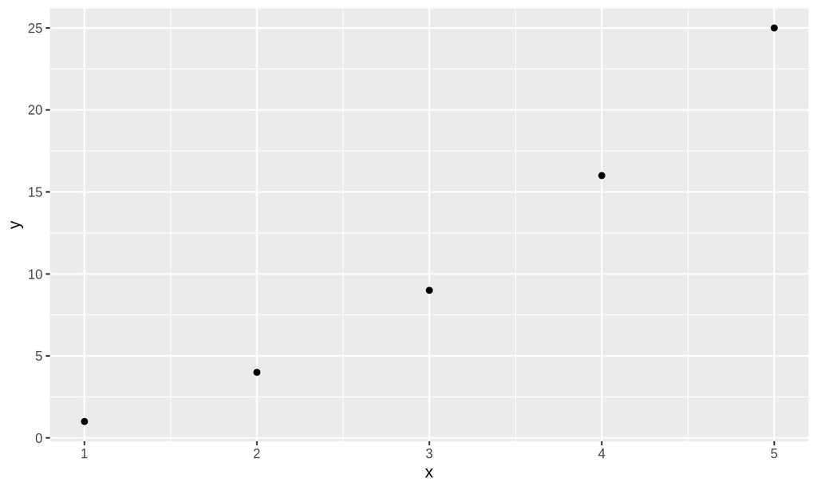

```r
data_frame(x = 1:5, y = x^2) %>%
  ggplot(aes(x, y)) + geom_point()
```

## Please give us a feedback

[figure not shown]

## Agenda - Part 1

**Block I 90 minutes**

- Introduction into R & RStudio
- Sources for learning and/or help
- Syntax and data structures
- Basic data imports (RData, csv, Excel)

**Break 30 minutes**

- Refreshments & Networking

**Block II 90 minutes**

- Basic data manipulation (dplyr)
- Basic vizualization (ggplot2)

## Where to find help

## RStudio cheat sheets

[figure not shown]

## StackOverflow

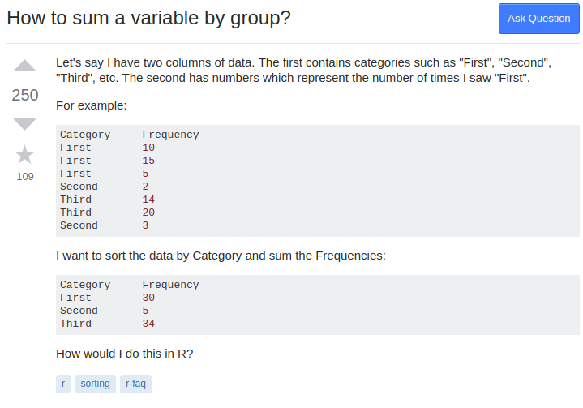

## RStudio Community

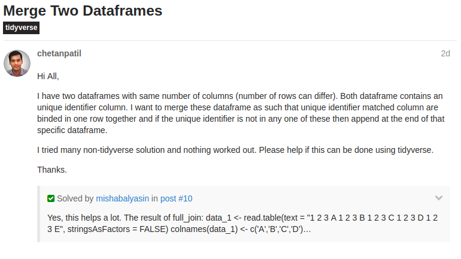

## Google

[figure not shown]

## R-bloggers

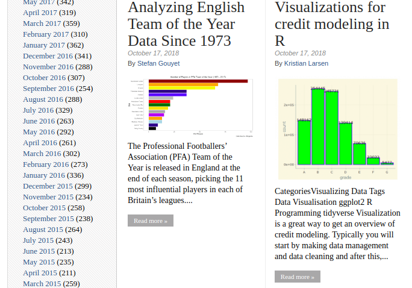

## Twitter #rstats

**Hadley Wickham**  
Chief Scientist at RStudio  
[@hadleywickham](https://twitter.com/hadleywickham)

**Jenny Bryan**  
Proffesor at UBC, DS at RStudio  
[@JennyBryan](https://twitter.com/jennybryan)

**Mara Averick**  
Inspirations for visualization  
[@dataandme](https://twitter.com/dataandme)

**David Robinson**  
Chief Data Scientist at DataCamp  
[@drob](https://twitter.com/drob)

## Time to start

- Make sure you have R & RStudio installed. Problems? Ask for help
- Open RStudio
- Create new project: **File > New Project… > New directory > New project**
- Always create new project before doing something

```r
install.packages(c("tidyverse", "repurrrsive"))
```

## Console scripting

## Vectors

Atomic:

- `logical`
- `integer`
- `numeric`
- `character`

Other:

- `list`

## Lists

*by Hadley Wickham*

## Working directory

- Do NOT use it
- Do NOT change it
- Do NOT touch it
- Do NOT even think of it
- Use projects instead

*… we will cover this in workshop **R for teams**.*

## RStudio look-around

## Shortcuts

- `alt` + `shift` + `k`: See all shortcuts
- `ctrl` + `shift` + `c`: comment / uncomment code
- `ctrl` + `shift` + `m`: pipe `%>%`

Most of shortcuts from other text editors works as well.

## Loading data

## `dplyr` functions

- `select()` select columns
- `filter()` filter rows
- `mutate()` create new columns
- `arrange()` re-order or arrange rows
- `summarise()` summarise values
- `group_by()` allows for group operations in the “split-apply-combine” concept

## Functional Programming

## Pipes

Shortcut: `ctrl` + `shift` + `m`

## Pipes

`x %>% f()` is equivalent to `f(x)`

`x %>% f(y)` is equivalent to `f(x, y)`

```r
mtcars %>%
  filter(hp >= 100) %>%
  mutate(cons = 235.215 / mpg) %>%
  rownames_to_column('model') %>%
  select(model, cons, hp, weight = wt)
```

is equivalent to

```r
select(rownames_to_column(mutate(filter(mtcars, hp >= 100), cons = 235.215 / mpg), 'model'),
       model, cons, hp, weight = wt)
```

## Data manipulation

```r
data('starwars')
```

Calculate:

- Average weight of all characters
- How many characters are from Alderaan
- What is the ratio (in percent) of humans

```
## # A tibble: 1 x 3
##   mean_mass num_alderaan ratio_humans
##       <dbl>        <int>        <dbl>
## 1      97.3            3         40.2
```

## Body mass index

```r
data('starwars')
```

Sort all characters by their BMI

\[ BMI = weight / height^2 [kg/m^2] \]

```
## # A tibble: 87 x 4
##    name                  height  mass   bmi
##    <chr>                  <int> <dbl> <dbl>
##  1 Jabba Desilijic Tiure    175  1358 443.
##  2 Dud Bolt                  94    45  50.9
##  3 Yoda                      66    17  39.0
##  4 Owen Lars                178   120  37.9
##  5 IG-88                    200   140  35
##  6 R2-D2                     96    32  34.7
##  7 Grievous                 216   159  34.1
##  8 R5-D4                     97    32  34.0
##  9 Jek Tono Porkins         180   110  34.0
## 10 Darth Vader              202   136  33.3
## # ... with 77 more rows
```

## The Force Awakens

```r
data('starwars')
```

## Mammals sleep

```r
msleep <- read_csv('data/msleep_ggplot2.csv', col_types = cols())
```

Get range and average value for sleep length in hours

```
## # A tibble: 1 x 3
##   avg_sleep min_sleep max_sleep
##       <dbl>     <dbl>     <dbl>
## 1      10.4       1.9      19.9
```

And now for carnivores / domesticated animals / primates / animals under 10kg only

```
## # A tibble: 1 x 4
##   vore  avg_sleep min_sleep max_sleep
##   <chr>     <dbl>     <dbl>     <dbl>
## 1 carni      10.4       2.7      19.4
```

## Grammar of Graphics

## `ggplot2` layers

Common layers:

- Base: `ggplot` (on data frames), `qplot` (on vectors)
- Aesthetics - specify `x`, `y`, `color`, `group`, `size`, …
- Geoms - points, lines, histogram, …
- Scales, axis settings, color palletes, labeling
- Facets
- Themes

Combine layers by adding (`+`), not pipes.

## Vizualization: examples

## Final plot - our goal

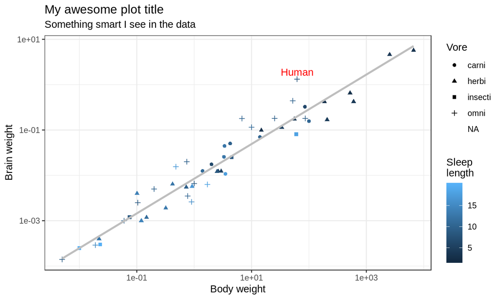

## Empty plot

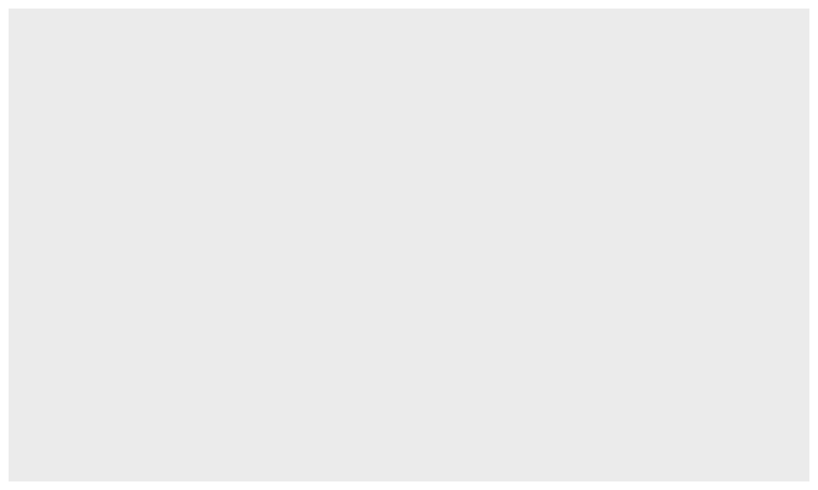

## Data without geoms

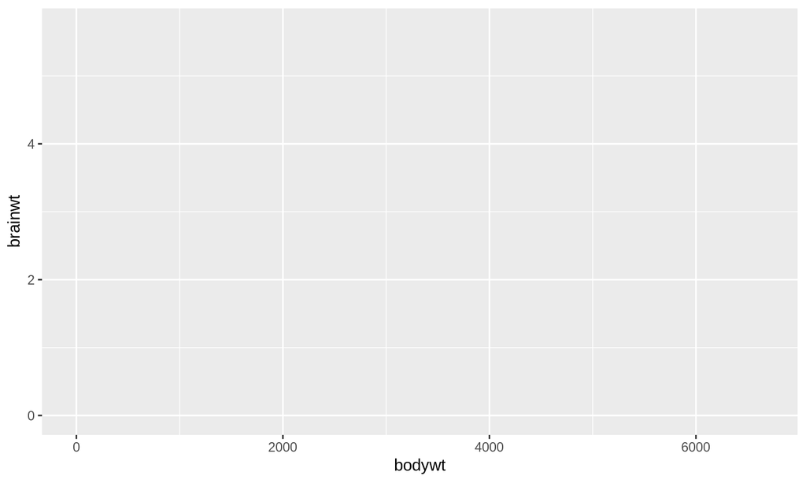

## Points

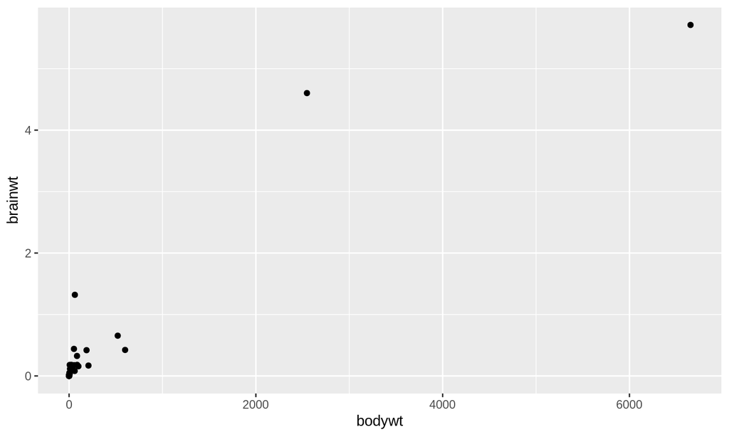

## Agenda - Part 2

**Block I 90 minutes**

- Data manipulation (dplyr, joining)
- Vizualization (ggplot2)
- Data imports (Excel, SQL)

**Break 30 minutes**

- Refreshments & Networking

**Block II 90 minutes**

- Manipulation of grouped data (dplyr)
- Vizualization of grouped data (ggplot2)
- Advanced data manipulation (dplyr, tidyr)

## Data manipulation: examples

## Logarithmic scale

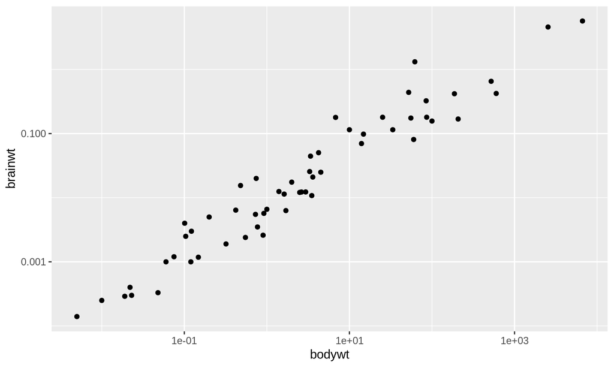

## Regression line

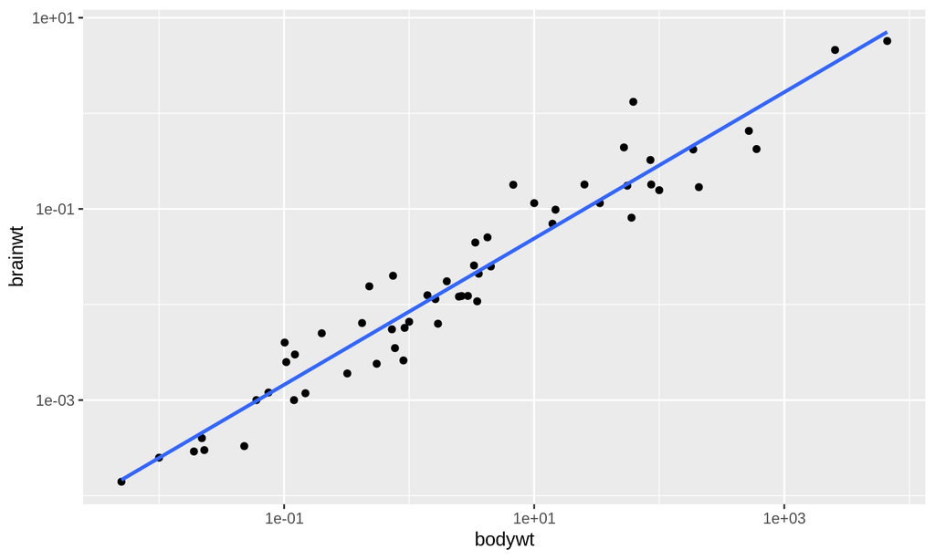

## Coloring (local aesthetics)

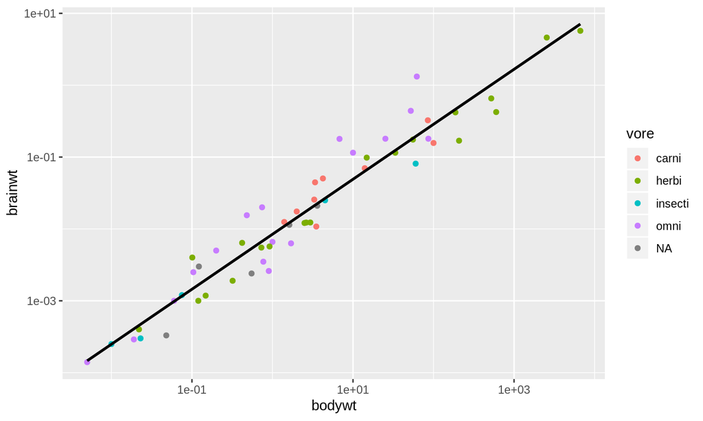

## Titles and labels

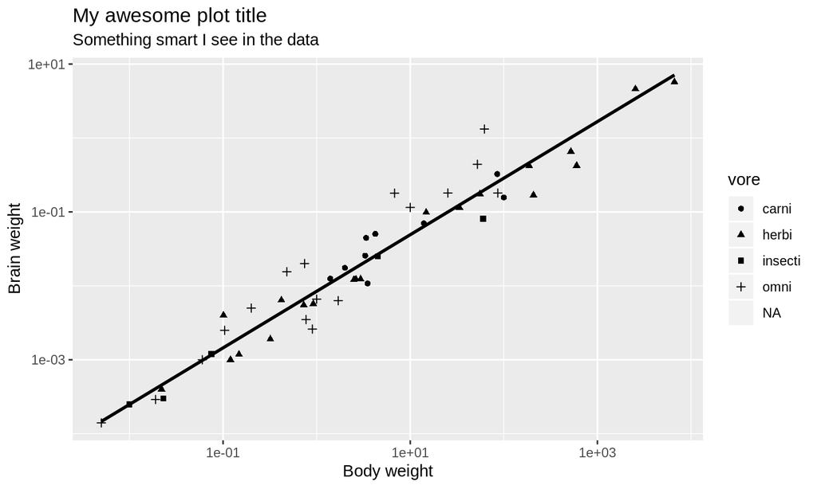

## Final plot

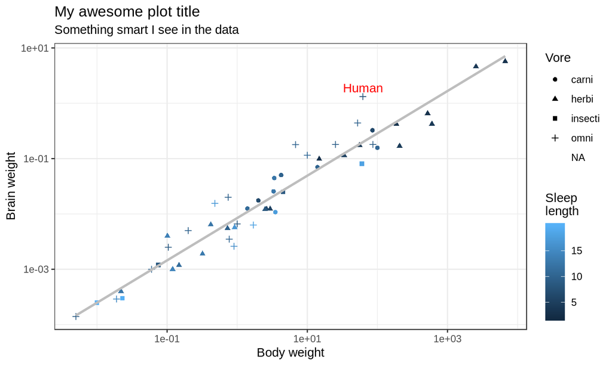

## Geometrics (most common)

Two numerical variables:

- geom_point
- geom_line
- geom_smooth

Numerical and categorical variable:

- geom_boxplot

One numerical variable:

- geom_histogram
- geom_density

One categorical variable:

- geom_bar

Each type requires different aesthetics - see help (e.g. `?geom_boxplot`).

## Boxplot

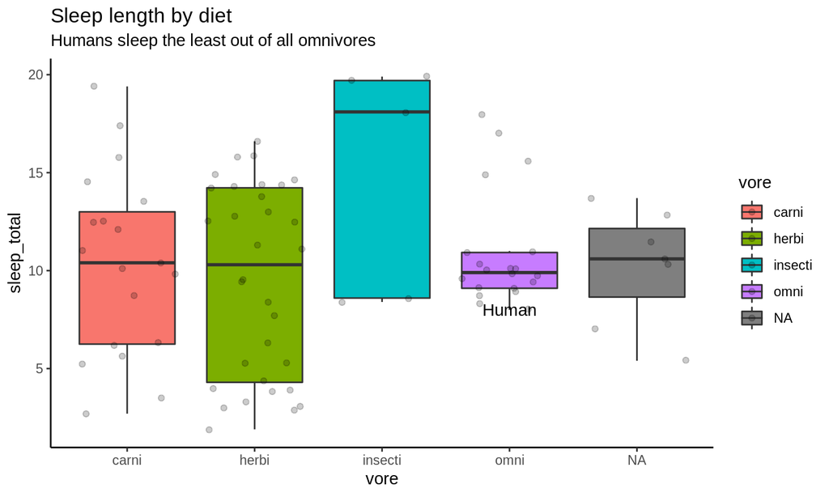

## Histogram

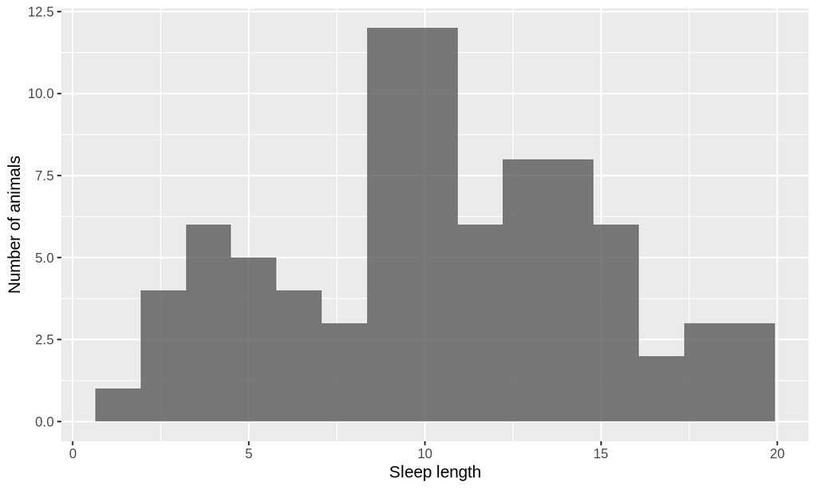

## Density

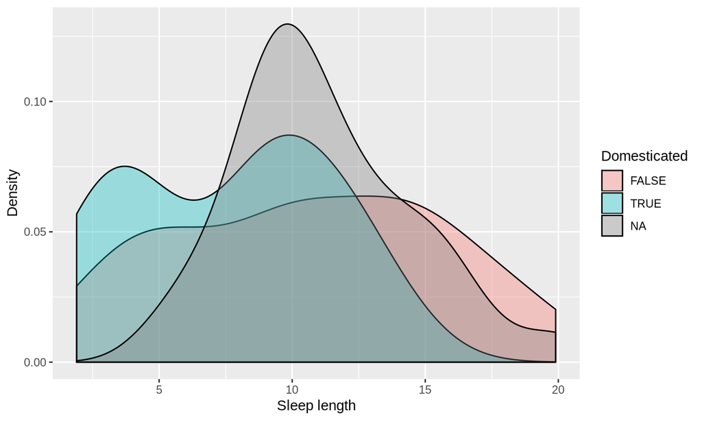

## Plotly

Different plotting library that creates interactive plots. It has significantly different syntax, but…

```r
install.packages('plotly')
require(plotly)
ggplotly(my_ggplot)
```

## Loading data

## Excel

It is easier to export data from Excel to csv and use `read_csv`. You might have to manually adjust the data to be readable by machine.

Go to website *opendata.praha.eu* and download "Roční statistika PID".

```r
require(readxl)
pid <- read_excel('data/statistika_pid.xlsx')
```

## SQL connection

Connection depends on type of database (MySQL, SQL Server, Postgres, SQLite, …; see `?dbConnect`) and database settings and location (credentials, dbname, host, port; contact your administrator).

```r
require(DBI)
require(RMySQL)
con <- dbConnect(drv = MySQL(),
                 user = "myname", password = "MyS3cr3tPa55word",
                 dbname = "main", host = "remote.example.com")
```

Then simply access any table

```r
mytable <- tbl(con, 'mytable')
```

## SQL example

```r
require(DBI)
require(RSQLite)
con <- dbConnect(SQLite(), 'data/starwars.sqlite')
tbl(con, 'sw_characters')
```

```
## # Source:   table<sw_characters> [?? x 10]
## # Database: sqlite 3.22.0
## #   [/home/jankislinger/personal/r-workshops/introduction/data/starwars.sqlite]
##    name     height  mass hair_color skin_color eye_color birth_year gender
##    <chr>     <int> <dbl> <chr>      <chr>      <chr>          <dbl> <chr>
##  1 Luke Sk…    172    77 blond      fair       blue            19   male
##  2 C-3PO       167    75 <NA>       gold       yellow         112   <NA>
##  3 R2-D2        96    32 <NA>       white, bl… red             33   <NA>
##  4 Darth V…    202   136 none       white      yellow          41.9 male
##  5 Leia Or…    150    49 brown      light      brown           19   female
##  6 Owen La…    178   120 brown, gr… light      blue            52   male
##  7 Beru Wh…    165    75 brown      light      blue            47   female
##  8 R5-D4        97    32 <NA>       white, red red             NA   <NA>
##  9 Biggs D…    183    84 black      light      brown           24   male
## 10 Obi-Wan…    182    77 auburn, w… fair       blue-gray       57   male
## # ... with more rows, and 2 more variables: homeworld <chr>, species <chr>
```

## SQL with dplyr

```r
tbl(con, 'sw_characters') %>%
  filter(species == 'Human') %>%
  mutate(bmi = mass / (height / 100)^2) %>%
  filter(!is.na(bmi)) %>%
  arrange(bmi) %>%
  select(name, bmi, gender)
```

```
## # Source:     lazy query [?? x 3]
## # Database:   sqlite 3.22.0
## #   [/home/jankislinger/personal/r-workshops/introduction/data/starwars.sqlite]
## # Ordered by: bmi
##    name               bmi gender
##    <chr>            <dbl> <chr>
##  1 Padmé Amidala     16.5 female
##  2 Dooku             21.5 male
##  3 Leia Organa       21.8 female
##  4 Raymus Antilles   22.4 male
##  5 Obi-Wan Kenobi    23.2 male
##  6 Boba Fett         23.4 male
##  7 Jango Fett        23.6 male
##  8 Anakin Skywalker  23.8 male
##  9 Mace Windu        23.8 male
## 10 Qui-Gon Jinn      23.9 male
## # ... with more rows
```

## SQL explained

```r
mytable <- tbl(con, 'sw_characters') %>%
  filter(species == 'Human') %>%
  mutate(bmi = mass / (height / 100)^2) %>%
  filter(!is.na(bmi)) %>%
  arrange(bmi) %>%
  select(name, bmi, gender)
explain(mytable)  # see SQL query
collect(mytable)  # load data as data frame
```

## Grouped data: examples

## Mammals sleep - grouped

Previously, we summarized data for all carnivores:

```
## # A tibble: 1 x 5
##   vore  count avg_sleep min_sleep max_sleep
##   <chr> <int>     <dbl>     <dbl>     <dbl>
## 1 carni    19      10.4       2.7      19.4
```

Now, we want to summarize data for each group.

```
## # A tibble: 5 x 5
##   vore    count avg_sleep min_sleep max_sleep
##   <chr>   <int>     <dbl>     <dbl>     <dbl>
## 1 carni      19     10.4        2.7      19.4
## 2 herbi      32      9.51       1.9      16.6
## 3 insecti     5     14.9        8.4      19.9
## 4 omni       20     10.9        8        18
## 5 <NA>        7     10.2        5.4      13.7
```

## Mammals sleep - grouped plot

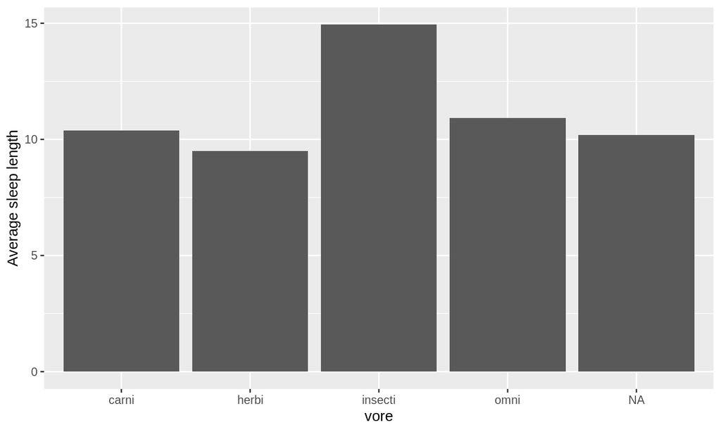

## Gapminder

```r
require(gapminder)
gapminder
```

```
## # A tibble: 1,704 x 6
##    country     continent  year lifeExp      pop gdpPercap
##    <fct>       <fct>     <int>   <dbl>    <int>     <dbl>
##  1 Afghanistan Asia       1952    28.8  8425333      779.
##  2 Afghanistan Asia       1957    30.3  9240934      821.
##  3 Afghanistan Asia       1962    32.0 10267083      853.
##  4 Afghanistan Asia       1967    34.0 11537966      836.
##  5 Afghanistan Asia       1972    36.1 13079460      740.
##  6 Afghanistan Asia       1977    38.4 14880372      786.
##  7 Afghanistan Asia       1982    39.9 12881816      978.
##  8 Afghanistan Asia       1987    40.8 13867957      852.
##  9 Afghanistan Asia       1992    41.7 16317921      649.
## 10 Afghanistan Asia       1997    41.8 22227415      635.
## # ... with 1,694 more rows
```

## Gapminder tasks

- How life expectancy evolved in your country?
- How was life expectancy and GDP per capita correlated in year 1987?
- How population of continents evolved?
- Select 5 largest economies and show how their ranks changed.
- Anything else you can show using the data.

## Advanced data manipulation

## Tidyr: gather & spread

- gather: wide table to long
- spread: long table to wide

But what does wide or long table mean?

- Long table - each observation on its own row (gapminder)
- Wide table - some grouping factors are used as columns (*"statistika PID"*)

Usually, it is easier to work with long tables using `group_by`.

## Wide to long

```r
gapminder %>%
  gather('variable', 'value', -country, -continent, -year)
```

```
## # A tibble: 5,112 x 5
##    country     continent  year variable value
##    <fct>       <fct>     <int> <chr>    <dbl>
##  1 Afghanistan Asia       1952 lifeExp   28.8
##  2 Afghanistan Asia       1957 lifeExp   30.3
##  3 Afghanistan Asia       1962 lifeExp   32.0
##  4 Afghanistan Asia       1967 lifeExp   34.0
##  5 Afghanistan Asia       1972 lifeExp   36.1
##  6 Afghanistan Asia       1977 lifeExp   38.4
##  7 Afghanistan Asia       1982 lifeExp   39.9
##  8 Afghanistan Asia       1987 lifeExp   40.8
##  9 Afghanistan Asia       1992 lifeExp   41.7
## 10 Afghanistan Asia       1997 lifeExp   41.8
## # ... with 5,102 more rows
```

## Long to wide

```r
gapminder %>%
  select(-pop, -gdpPercap) %>%
  spread('year', 'lifeExp')
```

```
## # A tibble: 142 x 14
##    country     continent `1952` `1957` `1962` `1967` `1972` `1977` `1982`
##    <fct>       <fct>      <dbl>  <dbl>  <dbl>  <dbl>  <dbl>  <dbl>  <dbl>
##  1 Afghanistan Asia        28.8   30.3   32.0   34.0   36.1   38.4   39.9
##  2 Albania     Europe      55.2   59.3   64.8   66.2   67.7   68.9   70.4
##  3 Algeria     Africa      43.1   45.7   48.3   51.4   54.5   58.0   61.4
##  4 Angola      Africa      30.0   32.0   34     36.0   37.9   39.5   39.9
##  5 Argentina   Americas    62.5   64.4   65.1   65.6   67.1   68.5   69.9
##  6 Australia   Oceania     69.1   70.3   70.9   71.1   71.9   73.5   74.7
##  7 Austria     Europe      66.8   67.5   69.5   70.1   70.6   72.2   73.2
##  8 Bahrain     Asia        50.9   53.8   56.9   59.9   63.3   65.6   69.1
##  9 Bangladesh  Asia        37.5   39.3   41.2   43.5   45.3   46.9   50.0
## 10 Belgium     Europe      68     69.2   70.2   70.9   71.4   72.8   73.9
## # ... with 132 more rows, and 5 more variables: `1987` <dbl>,
## #   `1992` <dbl>, `1997` <dbl>, `2002` <dbl>, `2007` <dbl>
```

## Wide to long: tasks

```r
pid <- read_excel('data/statistika_pid.xlsx')
```

- Convert table from wide to long
- Show coverage (in percent) of accessible transportation for different types
- Tell any story with the data

## Backup

Select only characters that appeared in movie *The Force Awakens* and sort them by number of means of transport.

```
## # A tibble: 11 x 3
##    name           num_means_of_transport num_means_by_type
##    <chr>                           <int> <chr>
##  1 Luke Skywalker                      4 2+2
##  2 Chewbacca                           3 1+2
##  3 Han Solo                            2 0+2
##  4 Leia Organa                         1 1+0
##  5 Poe Dameron                         1 0+1
##  6 R2-D2                               0 0+0
##  7 Ackbar                              0 0+0
##  8 Finn                                0 0+0
##  9 Rey                                 0 0+0
## 10 BB8                                 0 0+0
## 11 Captain Phasma                      0 0+0
```